# Assignment A:

# Question 3

1. Describe total number of prescriptions and their total actual cost (using the ACT COST column) across all practices for drugs related to:
   > - cardiovascular disease (British National Formulary chapter 2)
   > - antidepressants (British National Formulary chapter 4.3)

```python
# First select the presecriptions from the relevant chapter

cv_prescrip = prescribing[prescribing['BNF CODE'].str.startswith('02')]
ad_prescrip = prescribing[prescribing['BNF CODE'].str.startswith('0403')]
```

```python
# Duplicate the prescribing df and add a column which contains the first 2 letter of the BNF code
# Grouping the data by the BNF2 column allows us to check that there is only one group
cv_prescrip['BNF2'] = cv_prescrip['BNF CODE'].str[:2]
cv_prescrip_grouped = cv_prescrip.groupby(['BNF2'])
len(cv_prescrip_grouped)
```

```
1
```

```python
#Duplicate the prescribing df and add a column which contains the first 4 letters of the BNF code
# Grouping the data by the BNF4 column allows us to check that there is only one group
ad_prescrip['BNF4'] = ad_prescrip['BNF CODE'].str[:4]
ad_prescrip_grouped = ad_prescrip.groupby(['BNF4'])
len(cv_prescrip_grouped)
```

```
1
```

```python
# calcuate the number of prescriptions for cardiovascular medicines
cv_prescrip.ITEMS.sum()
```

```
26449832
```

```python
# calculate the cost of these prescriptions
cv_prescrip['ACT COST'].sum()
```

```
90193834.01999994
```

```python
# calculate the number of prescriptons related to Antidepressants
ad_prescrip.ITEMS.sum()
```

```
5715873
```

```python
# calculate the cost of antidepressants
ad_prescrip['ACT COST'].sum()
```

```
16853470.86
```

```python
# calculate the average presecription cost for a given treatment item
avg_medicine_cost = (prescribing['ACT COST'] / prescribing['ITEMS']).mean()
avg_medicine_cost
```

```
21.05
```

```python
# calculate the average cost of prescriptions related to cv medicines
avg_cv_prescript = (cv_prescrip['ACT COST'] / cv_prescrip['ITEMS']).mean()
avg_cv_prescript
```

```
11.45
```

```python
# calculate the average cost of prescriptions related to ad medicines
avg_ad_prescript = (ad_prescrip['ACT COST'] / ad_prescrip['ITEMS']).mean()
avg_ad_prescript
```

```
12.33
```

# Question 4

1. Describe the total spending and the relative costs per patient across all practices for the month of April 2018:
   > - visualize the monthly total spending per registered patients using a scatterplot and provide a trend line
   > - generate a histogram for relative spending for all practices and fit a Gaussian (normal) curve

#### Step 1. Combine prescribing data with GP prac demographic data to get the number of patients within the same df

```python
# create new df of combining prescrribing and gp prac demographics
prescribing_pat_num = prescribing.merge(gp_prac, how='inner', left_on=['PRACTICE'], right_on=['CODE'])

# check the new dataframe that is created
prescribing_pat_num.head()
```

|  | SHA | PCT | PRACTICE | BNF CODE | BNF NAME | ITEMS | NIC | ACT COST | QUANTITY | PERIOD | ... | PUBLICATION | EXTRACT_DATE | TYPE | CCG_CODE | ONS_CCG_CODE | CODE | POSTCODE | SEX | AGE | NUMBER_OF_PATIENTS |
| --- | --- | --- | --- | --- | --- | --- | --- | --- | --- | --- | --- | --- | --- | --- | --- | --- | --- | --- | --- | --- | --- |
| 0 | Q44 | RXA | Y04664 | 0101021B0BEAIAL | Gaviscon Advance_Liq (Aniseed) (Reckitt) | 9 | 61.44 | 57.09 | 6000 | 201804 | ... | GP_PRAC_PAT_LIST | 01APR2018 | GP | 02F | E38000196 | Y04664 | CH64 2TN | ALL | ALL | 4351 |
| 1 | Q44 | RXA | Y04664 | 0101021B0BEAQAP | Gaviscon Advance_Tab Chble Mint(Reckitt) | 2 | 15.35 | 14.26 | 300 | 201804 | ... | GP_PRAC_PAT_LIST | 01APR2018 | GP | 02F | E38000196 | Y04664 | CH64 2TN | ALL | ALL | 4351 |
| 2 | Q44 | RXA | Y04664 | 0101021B0BEBEAL | Gaviscon Advance_Liq (Peppermint) S/F | 7 | 33.98 | 31.60 | 3050 | 201804 | ... | GP_PRAC_PAT_LIST | 01APR2018 | GP | 02F | E38000196 | Y04664 | CH64 2TN | ALL | ALL | 4351 |
| 3 | Q44 | RXA | Y04664 | 0102000A0AAAAAA | Alverine Cit_Cap 60mg | 4 | 4.00 | 4.16 | 84 | 201804 | ... | GP_PRAC_PAT_LIST | 01APR2018 | GP | 02F | E38000196 | Y04664 | CH64 2TN | ALL | ALL | 4351 |
| 4 | Q44 | RXA | Y04664 | 0102000A0BBABAB | Spasmonal Fte_Cap 120mg | 1 | 29.13 | 27.13 | 90 | 201804 | ... | GP_PRAC_PAT_LIST | 01APR2018 | GP | 02F | E38000196 | Y04664 | CH64 2TN | ALL | ALL | 4351 |

5 rows × 21 columns

#### Step . Get total spend per practice

Group the merged df by CODE and get the total within each group

```python
# group the new df by CODE column
prescribing_grouped = prescribing_pat_num.groupby(['CODE'])
len(prescribing_grouped)

# See Appendix 1 for information on practices omitted during the selection process
```

```
7191
```

```python
# sum number of prescriptions in the "ITEMS" in each group, rename the "sum" column "TOTAL_ITEMS" and sort the values
practice_spend = prescribing_grouped['ACT COST'].sum().reset_index(name='TOTAL SPEND')

# check output
practice_spend.head(5)
```

|  | CODE | TOTAL SPEND |
| --- | --- | --- |
| 0 | A81001 | 52194.63 |
| 1 | A81002 | 268607.26 |
| 2 | A81004 | 139115.40 |
| 3 | A81005 | 102914.06 |
| 4 | A81006 | 183226.79 |

#### Step 3. Get total spend per patient for each practice

Merge the total spend per practice df with the gp_prac data and calculate necessary outputs

```python
# merge the practice spend file with the gp_prac file in order to calculate the spend per patient
spend_vs_numPat = practice_spend.merge(gp_prac, how='inner', on=['CODE'])

#check output
spend_vs_numPat.head(5)
```

|  | CODE | TOTAL SPEND | PUBLICATION | EXTRACT_DATE | TYPE | CCG_CODE | ONS_CCG_CODE | POSTCODE | SEX | AGE | NUMBER_OF_PATIENTS |
| --- | --- | --- | --- | --- | --- | --- | --- | --- | --- | --- | --- |
| 0 | A81001 | 52194.63 | GP_PRAC_PAT_LIST | 01APR2018 | GP | 00K | E38000075 | TS18 1HU | ALL | ALL | 4086 |
| 1 | A81002 | 268607.26 | GP_PRAC_PAT_LIST | 01APR2018 | GP | 00K | E38000075 | TS18 2AW | ALL | ALL | 19906 |
| 2 | A81004 | 139115.40 | GP_PRAC_PAT_LIST | 01APR2018 | GP | 00M | E38000162 | TS5 8SB | ALL | ALL | 10165 |
| 3 | A81005 | 102914.06 | GP_PRAC_PAT_LIST | 01APR2018 | GP | 00M | E38000162 | TS14 7DJ | ALL | ALL | 8016 |
| 4 | A81006 | 183226.79 | GP_PRAC_PAT_LIST | 01APR2018 | GP | 00K | E38000075 | TS18 2AT | ALL | ALL | 14497 |

```python
# mean total spend per practice
spend_vs_numPat['TOTAL SPEND'].mean()
```

```
87842.77
```

```python
# maximum spend
spend_vs_numPat['TOTAL SPEND'].max()
```

```
842838.1799999974
```

```python
## minimum spend
spend_vs_numPat['TOTAL SPEND'].min()
```

```
3.25
```

```python
spend_vs_numPat['TOTAL SPEND'].std()
```

```
59133.29
```

```python
spend_vs_numPat['TOTAL SPEND'].sum()
```

```
631677358.4000001
```

```python
spend_vs_numPat['NUMBER_OF_PATIENTS'].max()
```

```
72227
```

```python
spend_vs_numPat['NUMBER_OF_PATIENTS'].min()
```

```
3
```

```python
# to find out where the location of practice with the highest spend
spend_vs_numPat[spend_vs_numPat['TOTAL SPEND'] == 842838.1799999974]
```

|  | CODE | TOTAL SPEND | PUBLICATION | EXTRACT_DATE | TYPE | CCG_CODE | ONS_CCG_CODE | POSTCODE | SEX | AGE | NUMBER_OF_PATIENTS |
| --- | --- | --- | --- | --- | --- | --- | --- | --- | --- | --- | --- |
| 5491 | M85063 | 842838.18 | GP_PRAC_PAT_LIST | 01APR2018 | GP | 15E | E38000220 | B24 0SY | ALL | ALL | 66502 |

###### Figure 4

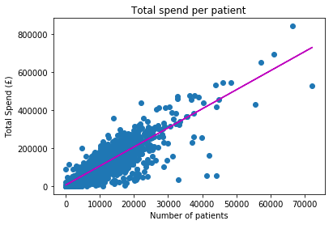

```python
# Create scatter plot. FIGURE 4
plt.scatter(spend_vs_numPat['NUMBER_OF_PATIENTS'], spend_vs_numPat['TOTAL SPEND'])

# Add trendline
x = spend_vs_numPat['NUMBER_OF_PATIENTS'].values
y = spend_vs_numPat['TOTAL SPEND'].values

z = np.polyfit(x, y, 1)
p = np.poly1d(z)

plt.plot(x, p(x), 'm-')

plt.xlabel('Number of patients')
plt.ylabel('Total Spend (£)')
plt.title('Total spend per patient')
plt.figure(figsize=(30,20))
plt.show()
```

##### Figure 5

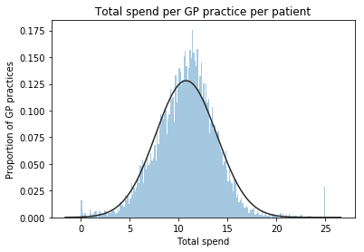

```python
# Create histogram Figure 5

from scipy.stats import norm

x = spend_vs_numPat['TOTAL SPEND']/spend_vs_numPat['NUMBER_OF_PATIENTS']

plt.xlabel('Total Spend per patient')
plt.ylabel('Proportion of GP practices')
plt.title('Total spend per GP practice per patient')

sns.distplot(x.clip(0,25), bins=200, fit=norm, kde=False, axlabel='Total spend', norm_hist=True)
```

# ASSIGNMENT B

## WHO Mortality Database

The WHO Mortality Database is a database of registered deaths compiled by WHO from data given by national authorities around the world. The cause of each death is classified by the circumstances that led to death. For this exercise, you will use data which report the cause of death using the 10th revision of the International Classification of Diseases (ICD-10). All of this information is collated into a number of Comma Separated Value (CSV) files, which can be found on the WHO Mortality Database website. The year of interest is 2010.  
Each country in the database is uniquely identified all WHO datasets by a four digit numeric code. The mapping between countries and identifier codes is located in the "Country codes" lookup file. Information on the population of each country is found in the "Population and live births" file.

```python
import urllib
import zipfile
urls = ['https://www.who.int/healthinfo/statistics/Morticd10_part1.zip', 'https://www.who.int/healthinfo/statistics/Morticd10_part2.zip',
        'https://www.who.int/healthinfo/statistics/country_codes.zip', 'https://www.who.int/healthinfo/Pop.zip']
for url in urls:
  urllib.request.urlretrieve(url, url.split('/')[-1])

for filepath in ['country_codes.zip', 'Morticd10_part1.zip', 'Morticd10_part2.zip', 'Pop.zip']:
  zip_ref = zipfile.ZipFile(filepath, 'r')
  zip_ref.extractall()
  zip_ref.close()

mortality1 = pd.read_csv('Morticd10_part1')
mortality2 = pd.read_csv('Morticd10_part2')
country_codes = pd.read_csv('country_codes')
pop = pd.read_csv('pop')
```

## Question 1.

What was the population and the total number of deaths (from all causes, all ages) in 2010 for:

- Iceland
- Italy
- New Zealand

#### Step 1. Set up data

```python
# combine mortality data files make files headers more more readable by changing the headers

all_deaths = pd.concat((mortality1, mortality2))

age_dict = {'Deaths1':'Total', 'Deaths2':'0', 'Deaths3':'1', 'Deaths4':'2', 'Deaths5':'3', 'Deaths6':'4',
            'Deaths7':'5-9', 'Deaths8':'10-14', 'Deaths9':'15-19', 'Deaths10':'20-24', 'Deaths11':'25-29',
            'Deaths12':'30-34', 'Deaths13':'35-39', 'Deaths14':'40-44', 'Deaths15':'45-49', 'Deaths16':'50-54',
            'Deaths17':'55-59', 'Deaths18':'60-64', 'Deaths19':'65-69', 'Deaths20':'70-74', 'Deaths21':'75-79',
            'Deaths22':'80-84', 'Deaths23':'85-89', 'Deaths24':'90-94', 'Deaths25':'95+', 'Deaths26':'Unspecified'}

pop_dict = {'Pop1':'Total', 'Pop2':'0', 'Pop3':'1', 'Pop4':'2', 'Pop5':'3', 'Pop6':'4',
            'Pop7':'5-9', 'Pop8':'10-14', 'Pop9':'15-19', 'Pop10':'20-24', 'Pop11':'25-29',
            'Pop12':'30-34', 'Pop13':'35-39', 'Pop14':'40-44', 'Pop15':'45-49', 'Pop16':'50-54',
            'Pop17':'55-59', 'Pop18':'60-64', 'Pop19':'65-69', 'Pop20':'70-74', 'Pop21':'75-79',
            'Pop22':'80-84', 'Pop23':'85-89', 'Pop24':'90-94', 'Pop25':'95+', 'Pop26':'Unspecified'}

specified_age_groups = ['0-4','5-9','10-14','15-19','20-24','25-29','30-34','35-39','40-44','45-49',
                        '50-54','55-59','60-64','65-69','70-74','75-79','80-84','85-89','90-94','95+']
```

```python
all_deaths = all_deaths.rename(index=str, columns=age_dict)
pop = pop.rename(index=str, columns=pop_dict)
all_deaths['0-4'] = all_deaths[['0', '1', '2', '3', '4']].sum(axis=1)
pop['0-4'] = pop[['0', '1', '2', '3', '4']].sum(axis=1)
```

```python
# Check new keys for pop
pop.head(5)
```

|  | Country | Admin1 | SubDiv | Year | Sex | Frmat | Total | 0 | 1 | 2 | ... | 65-69 | 70-74 | 75-79 | 80-84 | 85-89 | 90-94 | 95+ | Unspecified | Lb | 0-4 |
| --- | --- | --- | --- | --- | --- | --- | --- | --- | --- | --- | --- | --- | --- | --- | --- | --- | --- | --- | --- | --- | --- |
| 0 | 1060 | NaN | NaN | 1980 | 1 | 7 | 137100.0 | 3400.0 | 15800.0 | NaN | ... | 5300.0 | NaN | 2900.0 | NaN | NaN | NaN | NaN | 6500.0 | 5000.0 | 19200.0 |
| 1 | 1060 | NaN | NaN | 1980 | 2 | 7 | 159000.0 | 4000.0 | 18400.0 | NaN | ... | 6200.0 | NaN | 3400.0 | NaN | NaN | NaN | NaN | 7500.0 | 6000.0 | 22400.0 |
| 2 | 1125 | NaN | NaN | 1955 | 1 | 2 | 5051500.0 | 150300.0 | 543400.0 | NaN | ... | 51100.0 | 41600.0 | 14300.0 | 11800.0 | 25300.0 | NaN | NaN | 0.0 | 253329.0 | 693700.0 |
| 3 | 1125 | NaN | NaN | 1955 | 2 | 2 | 5049400.0 | 145200.0 | 551000.0 | NaN | ... | 51100.0 | 50700.0 | 15800.0 | 18000.0 | 28500.0 | NaN | NaN | 0.0 | 237901.0 | 696200.0 |
| 4 | 1125 | NaN | NaN | 1956 | 1 | 2 | 5353700.0 | 158700.0 | 576600.0 | NaN | ... | 54100.0 | 44000.0 | 14900.0 | 12400.0 | 26600.0 | NaN | NaN | 0.0 | 250022.0 | 735300.0 |

5 rows × 34 columns

```python
# Optional Check new keys for all_deaths
all_deaths.head(5)
```

|  | Country | Admin1 | SubDiv | Year | List | Cause | Sex | Frmat | IM_Frmat | Total | ... | 80-84 | 85-89 | 90-94 | 95+ | Unspecified | IM_Deaths1 | IM_Deaths2 | IM_Deaths3 | IM_Deaths4 | 0-4 |
| --- | --- | --- | --- | --- | --- | --- | --- | --- | --- | --- | --- | --- | --- | --- | --- | --- | --- | --- | --- | --- | --- |
| 0 | 1400 | NaN | NaN | 2001 | 101 | 1000 | 1 | 7 | 8 | 332 | ... | NaN | NaN | NaN | NaN | 0.0 | 8.0 | NaN | NaN | NaN | 10.0 |
| 1 | 1400 | NaN | NaN | 2001 | 101 | 1000 | 2 | 7 | 8 | 222 | ... | NaN | NaN | NaN | NaN | 0.0 | 11.0 | NaN | NaN | NaN | 12.0 |
| 2 | 1400 | NaN | NaN | 2001 | 101 | 1001 | 1 | 7 | 8 | 24 | ... | NaN | NaN | NaN | NaN | 0.0 | 0.0 | NaN | NaN | NaN | 0.0 |
| 3 | 1400 | NaN | NaN | 2001 | 101 | 1001 | 2 | 7 | 8 | 14 | ... | NaN | NaN | NaN | NaN | 0.0 | 0.0 | NaN | NaN | NaN | 0.0 |
| 4 | 1400 | NaN | NaN | 2001 | 101 | 1002 | 1 | 7 | 8 | 0 | ... | NaN | NaN | NaN | NaN | 0.0 | 0.0 | NaN | NaN | NaN | 0.0 |

5 rows × 40 columns

#### Calculate the population and total number deaths for iceland

```python
# first find the country code for Iceland
country_codes[country_codes['name'] == 'Iceland'].values
```

```
array([[4160, 'Iceland']], dtype=object)
```

```python
# find population data for 2010 in Iceland

# this give 2 rows - one for male and one for female
iceland_pop = pop[(pop['Year'] == 2010) & (pop['Country'] == 4160)]
iceland_deaths = all_deaths[(all_deaths['Year'] == 2010) & (all_deaths['Country'] == 4160)]
```

```python
iceland_pop['Total'].sum()
```

```
318041.0
```

```python
iceland_deaths['Total'].sum()
```

```
4038
```

#### Calculate the population and total number deaths for Italy

```python
# find country code for Italy
country_codes[country_codes.name == 'Italy'].values
```

```
array([[4180, 'Italy']], dtype=object)
```

```python
# find population data for 2010 in Italy

# this give 2 rows - one for male and one for female
italy_pop_2010 = pop[(pop['Year'] == 2010) & (pop['Country'] == 4180)]
italy_deaths_2010 = all_deaths[(all_deaths['Year'] == 2010) & (all_deaths['Country'] == 4180)]
```

```python
# Total population in 2010
italy_pop_2010['Total'].sum()
```

```
60483386.0
```

```python
# Total number deaths in 2010
italy_deaths_2010['Total'].sum()
```

```
1169230
```

#### Calculate the population and total number deaths for New Zealand

```python
country_codes[country_codes['name'] == 'New Zealand'].values
```

```
array([[5150, 'New Zealand']], dtype=object)
```

```python
# find population data for 2010 in Italy

# this give 2 rows - one for male and one for female
nz_pop = pop[(pop['Year'] == 2010) & (pop['Country'] == 5150)]
nz_deaths = all_deaths[(all_deaths['Year'] == 2010) & (all_deaths['Country'] == 5150)]
```

```python
# Population of New Zealand
nz_pop['Total'].sum()
```

```
4367360.0
```

```python
# Total number deaths
nz_deaths['Total'].sum()
```

```
57298
```

# Question 2

What was the distribution of deaths (all causes, all years) by age group in Italy?

- Visualise the results using a histogram.

```python
# First select all of the deaths for Italy
italy_all_deaths = all_deaths[all_deaths['Country'] == 4180]

# Now sum the totals for the specified age groups (dictionary created previously) and divide by the total of each column
italy_all_deaths_hist = italy_all_deaths[specified_age_groups].sum() / italy_all_deaths[specified_age_groups].sum().sum()
```

##### Figure 6

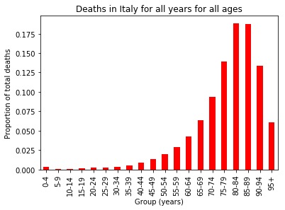

```python
# Figure 6
# Create a plot of the summed data and modify aspects of the graph
italy_all_deaths_hist.plot.bar(x=[0], y=[1], color = 'r')
plt.title('Deaths in Italy for all years for all ages')
plt.ylabel('Proportion of total deaths')
plt.xlabel('Group (years)')
plt.show()
```

## Questions 3

What were the top five causes of death (top five ICD-10 terms) in Italy across all years for the Neoplasm ICD10-category (C00-D48)?

- Generate a table with the cause of death, the number of deaths, and the proportion of overall deaths.
- Generate a pie chart to visualize the proportion of deaths.

#### Step 1. Generate table for top 5 neoplasm causes of death

```python
# Extract the data for C00-D48 codes first
italy_neoplasms = italy_all_deaths[italy_all_deaths['Cause'].str.startswith(('C', 'D0', 'D1', 'D2', 'D3', 'D4'))]

# group them by cause and sum the values in each group
italy_neoplasms_grouped = italy_neoplasms.groupby('Cause').agg({'Total' : 'sum'}).reset_index()

# create a new column in the grouped df with the percentage that each cause accounts for
italy_neoplasms_grouped['Percentage'] = italy_neoplasms_grouped['Total']/ italy_neoplasms_grouped['Total'].sum()*100
```

##### Table 9

```python
# Table 9
# sort the data in descending order and generate table from the
italy_neoplasms_sorted = italy_neoplasms_grouped.sort_values('Total', ascending=False)
italy_neoplasms_top5 = italy_neoplasms_sorted.head(5)
italy_neoplasms_top5
```

|  | Cause | Total | Percentage |
| --- | --- | --- | --- |
| 143 | C349 | 426451 | 18.964664 |
| 227 | C509 | 155895 | 6.932792 |
| 92 | C189 | 143188 | 6.367701 |
| 76 | C169 | 125679 | 5.589059 |
| 118 | C259 | 120070 | 5.339622 |

#### Step 2. Generate table with top 5 causes + all other causes

```python
# first calculate what percentage the other ICD10 codes account for
Total_minus_top5 = italy_neoplasms_grouped['Total'].sum() - italy_neoplasms_top5["Total"].sum()

# create another df for other neoplasms and add it to the top 5 df
other_neoplasms = {'Cause' : 'Other neoplasms', 'Total' : [Total_minus_top5], 'Percentage' : 100-italy_neoplasms_top5.Percentage.sum()}
other_neoplasms_df = pd.DataFrame(other_neoplasms)

all_neoplasms = pd.concat ((italy_neoplasms_top5, other_neoplasms_df))
all_neoplasms
```

|  | Cause | Total | Percentage |
| --- | --- | --- | --- |
| 143 | C349 | 426451 | 18.964664 |
| 227 | C509 | 155895 | 6.932792 |
| 92 | C189 | 143188 | 6.367701 |
| 76 | C169 | 125679 | 5.589059 |
| 118 | C259 | 120070 | 5.339622 |
| 0 | Other neoplasms | 1277378 | 56.806162 |

#### Step 3. Generate pie chart of results

##### Figure 7

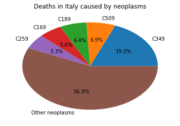

```python
# Figure 7

# plot a pie chart with the data from the all_neoplasms df
plt.pie(all_neoplasms.Percentage, labels=all_neoplasms.Cause, autopct='%1.1f%%')
plt.title('Deaths in Italy caused by neoplasms')
plt.show()
```

# Question 4

Are there differences by age group for deaths from Neoplasms (C00-D48) in Australia for 2010?

- Identify the top five age groups in Australia dying with a Neoplasms cause of death.

#### Step 1. Get Australia country code, use it to extract relevant info for Australia from mortality data

```python
# First get Australia country code
country_codes[country_codes['name'] == 'Australia'].values
```

```
array([[5020, 'Australia']], dtype=object)
```

```python
# extract australia information
aus_all_deaths = all_deaths[all_deaths['Country'] == 5020]

# extract rows for deaths attributed to neoplasms
aus_neoplasms = aus_all_deaths[aus_all_deaths['Cause'].str.startswith(('C', 'D0', 'D1', 'D2', 'D3', 'D4'))]

# extract rows data related to 2010
aus_neoplasms_2010 = aus_neoplasms[aus_neoplasms['Year'] == 2010]

# sum the age group columns
aus_neoplasms_2010_by_age = aus_neoplasms_2010[specified_age_groups].sum()

# check the output
aus_neoplasms_2010_by_age
```

```
0-4      44.0
5-9      46.0
10-14    31.0
15-19    50.0
20-24    52.0
25-29    97.0
30-34    138.0
35-39    323.0
40-44    548.0
45-49    1065.0
50-54    1756.0
55-59    2695.0
60-64    3938.0
65-69    4768.0
70-74    5713.0
75-79    6291.0
80-84    7167.0
85-89    5520.0
90-94    2336.0
95+      735.0
dtype: float64
```

#### Step 2. Create bar chart to visulaise comparison between age groups

##### Figure 8

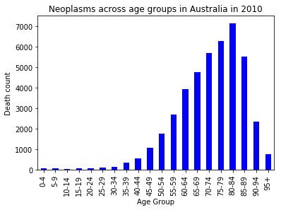

```python
#Figure 8: Neoplasms across age groups in Australia in 2010

# create bar chart to see if there are differences in ages
aus_neoplasms_2010_by_age.plot.bar(x=[0], y=[1], color = 'b')
plt.title('Neoplasms across age groups in Australia in 2010')
plt.ylabel('Death count')
plt.xlabel('Age Group')
plt.show()
```

#### Step 3. Identify top 5 age groups for neoplasms

```python
# identify the top 5 age groups where neoplasms are the cause of death
aus_neoplasms_2010_by_age.nlargest(5)
```

```
80-84    7167.0
75-79    6291.0
70-74    5713.0
85-89    5520.0
65-69    4768.0
dtype: float64
```

# Question 5

Compare and contrast the frequency of deaths by Neoplasms in Italy and Australia in 2010.

- Combine information on the population and deaths and describe your logic.
- Use descriptive statistics and plots.

#### Step 1. Calculate the frequency of deaths by neoplasms

```python
# First get the 2010 data for Italy neoplasms. Already have population data for italy 2010
italy_neoplasms_2010 = italy_neoplasms[italy_neoplasms['Year'] == 2010]
```

```python
# Get population information that we need for Australia
aus_pop_2010 = pop[(pop['Year'] == 2010) & (pop['Country'] == 5020)]
```

```python
# Calculate the frequency of deaths for each country
aus_death_freq = aus_neoplasms_2010.Total.sum() / aus_pop_2010.Total.sum() * 100000
italy_death_freq = italy_neoplasms_2010.Total.sum() / italy_pop_2010.Total.sum() * 100000

# Declare information
print('Italy')
print('Deaths caused by neoplasms per 100,000 of the population: ' + str(italy_death_freq))
print('-----------------')
print('Australia')
print('Deaths caused by neoplasms per 100,000 of the population: ' + str(aus_death_freq))
```

```
Italy
Deaths caused by neoplasms per 100,000 of the population: 289.41170720832326
-----------------
Australia
Deaths caused by neoplasms per 100,000 of the population: 194.26380024859273
```

#### Step 2. Get information required to make a bar chart for Italy v Australia. Do as have done for australia in question 4.

```python
# sum the age group columns
italy_neoplasms_2010_by_age = italy_neoplasms_2010[specified_age_groups].sum()
```

```python
# get all deaths for australia in 2010
aus_all_deaths_2010 = all_deaths[(all_deaths['Country'] == 5020) & (all_deaths['Year'] == 2010)]
```

#### Step 3. Create a bar chart to compare the number deaths caused by neoplasms in 2010 in Italy and Australia

```python
# calculate the number of deaths for each age group, make a new df and create a bar chart
italy_counts = np.array(italy_neoplasms_2010[specified_age_groups].sum())
aus_counts = np.array(aus_neoplasms_2010[specified_age_groups].sum())
counts_index = italy_neoplasms_2010[specified_age_groups].sum().index
italy_vs_aus_count = pd.DataFrame({'Italy': italy_counts, 'Australia':aus_counts}).set_index(counts_index)
```

##### Figure 9

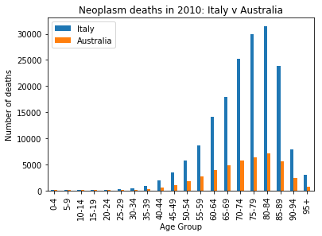

```python
# Figure 9
# plot a bar graph to illustrate
italy_vs_aus_count.plot.bar()
plt.title('Neoplasm deaths in 2010: Italy v Australia')
plt.ylabel('Number of deaths')
plt.xlabel('Age Group')
plt.show()
```

#### Step 4. Create a bar chart of the neoplasm deaths in 2010 as a percentage of all deaths for a given age group. Plot Italy and Austrlia data on graph for comparison

```python
# calculate neoplasm deaths as a percentage of all deaths for each age group
italy_percentage_neoplasm_deaths = italy_neoplasms_2010[specified_age_groups].sum() / italy_deaths_2010[specified_age_groups].sum() *100
aus_percentage_neoplasm_deaths = aus_neoplasms_2010[specified_age_groups].sum() / aus_all_deaths_2010[specified_age_groups].sum() *100

# create a new df with the percentage neoplasm data
age_groups = np.array(aus_percentage_neoplasm_deaths.index)
italy_array = np.array(italy_percentage_neoplasm_deaths)
aus_array = np.array(aus_percentage_neoplasm_deaths)
italy_vs_aus = pd.DataFrame({'Italy': italy_array, 'Australia':aus_array}).set_index(age_groups)
```

##### Figure 10

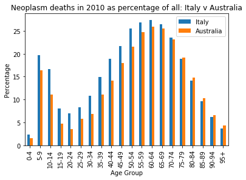

```python
#Figure 10
# plot a bar graph to illustrate
italy_vs_aus.plot.bar()
plt.title('Neoplasm deaths in 2010 as percentage of all: Italy v Australia')
plt.ylabel('Percentage')
plt.xlabel('Age Group')
plt.show()
```

# Appendix 1 - difference between prescribing and gp demographic data

```python
# group prescribing data by practice
prescribing_grouped = prescribing.groupby(['PRACTICE'])
len(prescribing_grouped)
```

```
9578
```

```python
# group prescribing data by practice (CODE column)
gp_prac_grouped = gp_prac.groupby(['CODE'])
len(gp_prac_grouped)
```

```
7241
```

```python
# what practices in prescibing data but not in gp demographic data
uncommon = prescribing[~prescribing['PRACTICE'].isin(gp_prac['CODE'])].dropna()
uncommon
uncommon_grouped = uncommon.groupby(['PRACTICE'])
len(uncommon_grouped)
```

```
2387
```

```python
# what practices in gp demogrpahic data but not in prescribing data
uncommon2 = gp_prac[~gp_prac['CODE'].isin(prescribing['PRACTICE'])].dropna()
uncommon2_grouped = uncommon2.groupby(['CODE'])
len(uncommon2_grouped)
```

```
50
```

```python
# total cost of prescriptions for GPs not in GP demographic data file
uncommon['ACT COST'].sum()
```

```
11510031.8
```